# Hands_on_I

### 2.1.4 Bivariate EDA for Numerical Variables

In order to visualize the relationships between numerical variables, scatterplots were performed. Besides, for each plot, the correlation coefficient (r) was calculated to quantify the strength and direction of the relationship. These revealed very weak relations between the different numerical variables. The higher r value was found between age and talach, showing a negative correlation, meaning that while we age the maximum heart rate decreases.

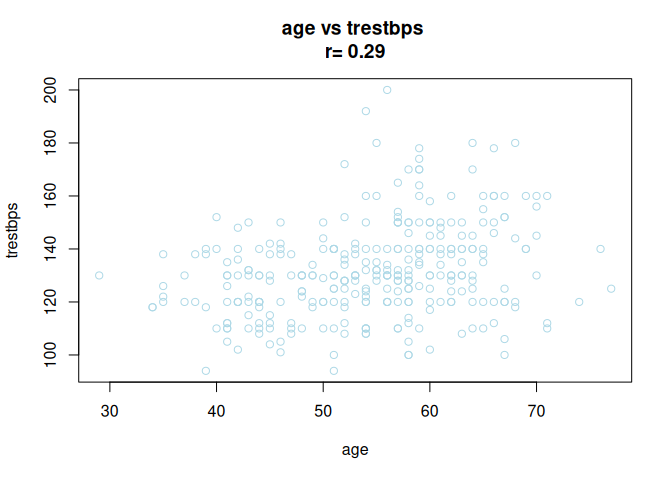

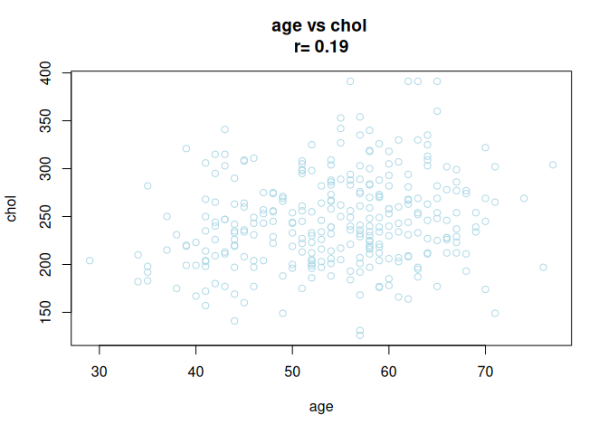

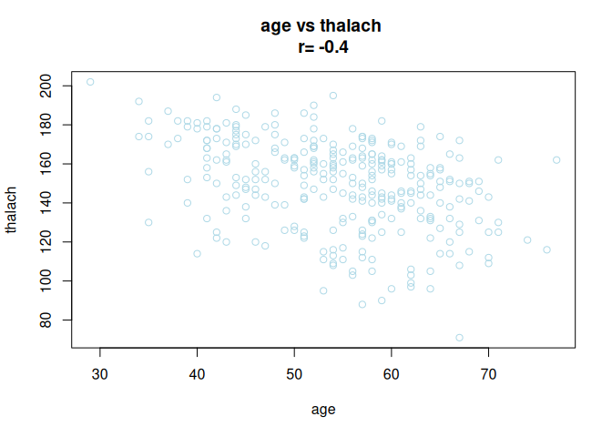

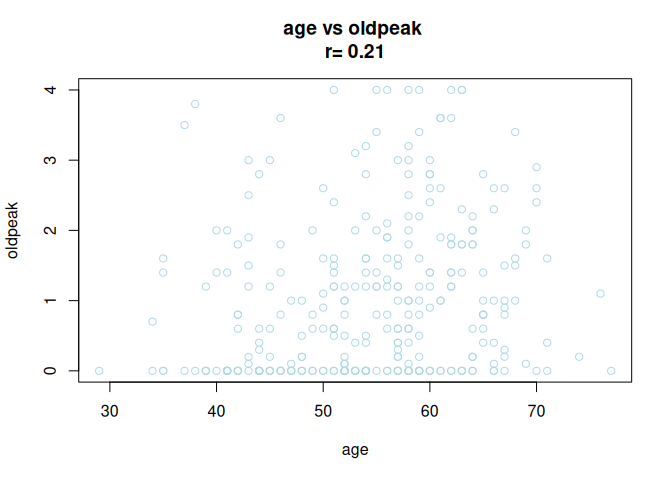

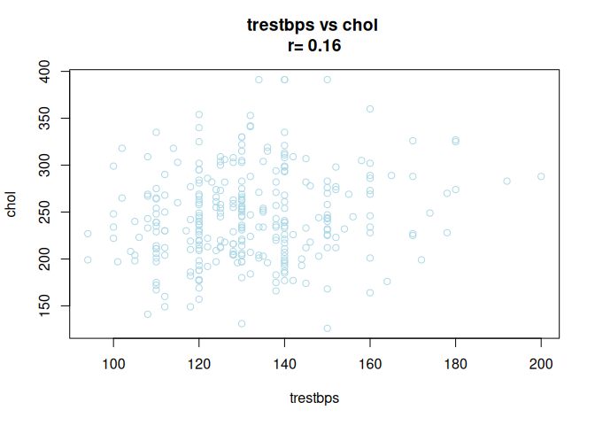

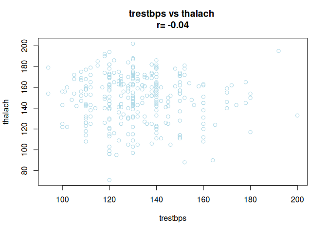

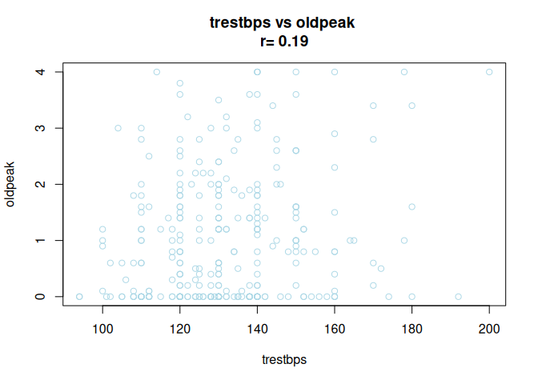

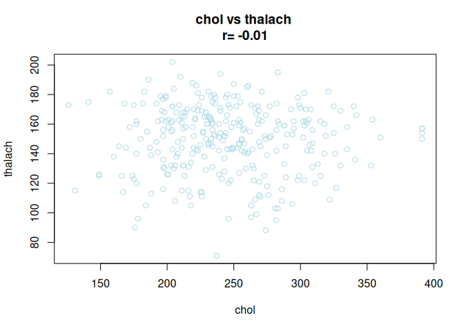

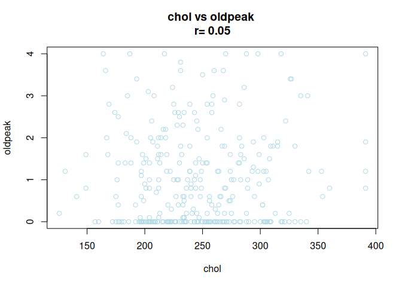

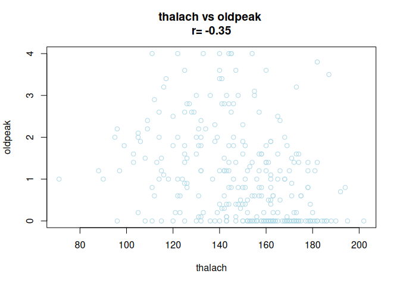

```r
numeric_names <- names(imp_heart_disease)[sapply(imp_heart_disease, is.numeric)]

# scatterplots
for (i in 1:(length(numeric_names)-1)){
  for (j in (i+1):length(numeric_names)){
    cor_coef <- cor(imp_heart_disease[[numeric_names[i]]], imp_heart_disease[[numeric_names[j]]])
    plot(
      imp_heart_disease[[numeric_names[i]]],
      imp_heart_disease[[numeric_names[j]]],
      main = paste(numeric_names[i], "vs", numeric_names[j], "\nr=", round(cor_coef, 2)),
      xlab = numeric_names[i],
      ylab = numeric_names[j],
      col = "lightblue"
    )
  }
}
```

In addition, a correlation matrix was performed to summarize the pairwise correlations between all numerical variables and this was visualized using corrplot package. The matrix confirmed the weak relations between the numerical variables. Showing the highest relation between age and thalach (max heart rate) and showing also less significant relations like thalach with oldpeak (ST depression) or age with trestbps (resting blood pressure).

```r
# Correlation matrix for numerical variables
correlation_matrix <- cor(imp_heart_disease[, numeric_cols], use = "complete.obs")
print(correlation_matrix)
```

```
##                 age    trestbps        chol     thalach     oldpeak
## age       1.0000000  0.29069132  0.19289565 -0.39731587  0.20518610
## trestbps  0.2906913  1.00000000  0.15996658 -0.04400039  0.18638681
## chol      0.1928957  0.15996658  1.00000000 -0.01462828  0.04939164
## thalach  -0.3973159 -0.04400039 -0.01462828  1.00000000 -0.34917160
## oldpeak   0.2051861  0.18638681  0.04939164 -0.34917160  1.00000000
```

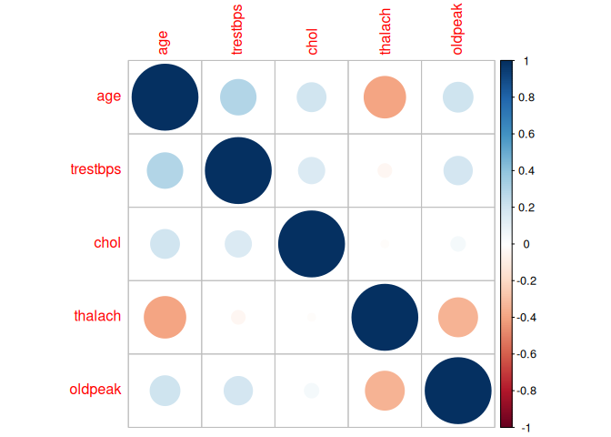

```r
# Visualize correlation matrix using corrplot
corrplot(correlation_matrix, method = "circle")
```

## 2.2 Create visualizations in order to show which variables seem to be more associated with heart disease

```r
# Taking into account num categorical variable is diagnosis, first factorize it
imp_heart_disease$num <- as.factor(imp_heart_disease$num)

# Logistic regression model with all varriables
log_model <- glm(num ~ ., data = imp_heart_disease, family = binomial)
summary(log_model)
```

```
##
## Call:
## glm(formula = num ~ ., family = binomial, data = imp_heart_disease)
##
## Coefficients:
##                      Estimate Std. Error z value Pr(>|z|)
## (Intercept)        -7.3446249  2.8735165  -2.556 0.010589 *
## age                -0.0095423  0.0239180  -0.399 0.689925
## sexmale             1.4158159  0.4994003   2.835 0.004582 **
## cpatypical          1.2048217  0.8348925   1.443 0.148996
## cpnon-anginal       0.9865874  0.7349338   1.342 0.179461
## cpasymptomatic      2.4992958  0.7242680   3.451 0.000559 ***
## trestbps            0.0297386  0.0111603   2.665 0.007707 **
## chol               -0.0004349  0.0042497  -0.102 0.918481
## fbs>120 mg/dl      -0.7989312  0.5514217  -1.449 0.147378
## restecgabnormality  0.7201131  1.5723382   0.458 0.646961
## restecghypertrophy  0.8926910  0.3768277   2.369 0.017838 *
## thalach            -0.0111091  0.0104086  -1.067 0.285840
## exangyes            0.3929686  0.4260930   0.922 0.356393
## oldpeak             0.1197407  0.2204217   0.543 0.586968
## slopeflat           1.3114442  0.4673862   2.806 0.005017 **
## slopedownsloping    0.3404607  0.8831117   0.386 0.699849
## ca1                 1.5518212  0.4604943   3.370 0.000752 ***
## ca2                 2.9904411  0.7054113   4.239 2.24e-05 ***
## ca3                 1.0092500  0.7271475   1.388 0.165150
## thalfixed          -1.8316738  0.8351342  -2.193 0.028288 *
## thalreversable      1.3758659  0.4149276   3.316 0.000913 ***
## ---
## Signif. codes:  0 '***' 0.001 '**' 0.01 '*' 0.05 '.' 0.1 ' ' 1
##
## (Dispersion parameter for binomial family taken to be 1)
##
##     Null deviance: 406.66  on 301  degrees of freedom
## Residual deviance: 204.92  on 281  degrees of freedom
## AIC: 246.92
##
## Number of Fisher Scoring iterations: 6
```

```r
# Convert log odds to odd ratios for better understanding
odds_ratios <- exp(coef(log_model))
odds_ratios
```

```
##        (Intercept)                age            sexmale         cpatypical
##       6.460556e-04       9.905031e-01       4.119846e+00       3.336164e+00
##      cpnon-anginal     cpasymptomatic           trestbps               chol
##       2.682066e+00       1.217392e+01       1.030185e+00       9.995651e-01
##      fbs>120 mg/dl restecgabnormality restecghypertrophy            thalach
##       4.498095e-01       2.054666e+00       2.441692e+00       9.889524e-01
##           exangyes            oldpeak          slopeflat   slopedownsloping
##       1.481372e+00       1.127205e+00       3.711530e+00       1.405595e+00
##                ca1                ca2                ca3          thalfixed
##       4.720058e+00       1.989446e+01       2.743543e+00       1.601453e-01
##     thalreversable
##       3.958503e+00
```

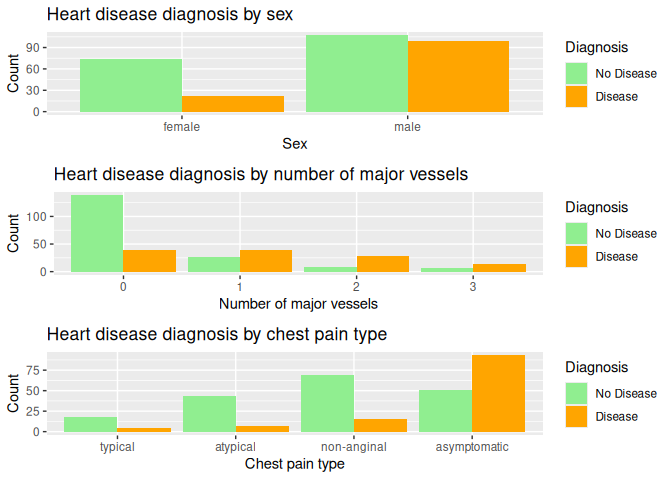

```r
# Barplot for sex vs num
sex_plot <- ggplot(imp_heart_disease, aes(x = sex, fill = factor(num))) +
  geom_bar(position = "dodge") +
  labs(title = "Heart disease diagnosis by sex", x = "Sex", y = "Count", fill = "Diagnosis") +
  scale_fill_manual(values = c("lightgreen", "orange"), labels = c("No Disease", "Disease"))

# Barplot for ca vs num
ca_plot <- ggplot(imp_heart_disease, aes(x = factor(ca), fill = factor(num))) +
  geom_bar(position = "dodge") +
  labs(title = "Heart disease diagnosis by number of major vessels", x = "Number of major vessels", y = "Count", fill = "Diagnosis") +
  scale_fill_manual(values = c("lightgreen", "orange"), labels = c("No Disease", "Disease"))


# Barplot for cp vs num
cp_plot <- ggplot(imp_heart_disease, aes(x = factor(cp), fill = factor(num))) +
  geom_bar(position = "dodge") +
  labs(title = "Heart disease diagnosis by chest pain type", x = "Chest pain type", y = "Count", fill = "Diagnosis") +
  scale_fill_manual(values = c("lightgreen", "orange"), labels = c("No Disease", "Disease"))


grid.arrange(sex_plot, ca_plot, cp_plot)
```

# 3 Difference in mortality rates in hospitalized COVID-19 patients

Using the supplementary material from the [Difference in mortality rates in hospitalized COVID-19 patients identified by cytokine profile clustering using a machine learning approach: An outcome prediction alternative](https://www.frontiersin.org/articles/10.3389/fmed.2022.987182/full), perform the following tasks

## 3.1 Reproduce Figure 1 from the publication

### 3.1.1 Data Preparation

First, patient data was processed by converting excel serial dates into proper formats and replacing missing values (“NI”) with NA. Numeric values stored as characters were standardized by replacing commas with dots and converting applicable entries to numeric format. Binary categorical variables were refined to contain only “Yes” or “No” values. Additionally, an automated classification system was implemented to update binary variables based on corresponding numerical indicators, ensuring logical coherence.

```r
# Import Data
data <- read_excel("data/Table1.xlsx", skip = 1)

# Correct the data format
data$`Hospitalization date` <- as.Date(as.numeric(data$`Hospitalization date`), origin = "1899-12-30")
data$`Syntoms onset` <- as.Date(as.numeric(data$`Syntoms onset`), origin = "1899-12-30")

# Replace "NI" with NA
data <- data %>%
  mutate(across(where(is.character), ~ na_if(., "NI")))

# Replace commas with dots in all character columns and convert to numeric if applicable
data <- data %>%
  mutate(across(where(is.character), ~ gsub(",", ".", .))) %>%
  mutate(across(where(is.character), ~ ifelse(grepl("^[0-9.]+$", .), as.numeric(.), .)))

# Replace values in specified columns that are not "Yes" or "No" with NA
data <- data %>%
  mutate(across(
    c(`Admission to ICU`, `ARDS Diagnosis`, `CRS Diagnosis`, `Use of NIV`, `Use of AMV`, Death),  # Replace with your column names
    ~ ifelse(. %in% c("Yes", "No"), ., NA)
  ))

## Automating the Update of Binary Status Columns ('Yes'/'No') Based on Associated Numeric Thresholds Across Multiple Variable Pairs in Patient Data

# Define the column pairs: First column to update, second column for condition
column_pairs <- list(
  c("Admission to ICU", "Days in ICU"),
  c("ARDS Diagnosis", "Days with ARDS"),
  c("CRS Diagnosis", "Days with CRS"),
  c("Use of NIV", "Days with NIV"),
  c("Use of AMV", "Days with AMV")
)

# Apply the logic to each pair
for (pair in column_pairs) {
  column_to_update <- pair[1]
  condition_column <- pair[2]

  data <- data %>%
    mutate(!!sym(column_to_update) := case_when(
      !!sym(condition_column) > 0 ~ "Yes",
      !!sym(condition_column) == 0 ~ "No",
      TRUE ~ .data[[column_to_update]] # Retain existing value if not covered by conditions
    ))
}
```

To ensure data completeness and consistency, records with missing “Death” status were removed. Additionally, duplicate patient entries were identified and addressed by retaining only one instance if all values were identical; otherwise, duplicates were eliminated to prevent inconsistencies in the analysis.

```r
# Remove rows where the column Death is NA
complete_data <- data %>% filter(!is.na(Death) & Death != "")

# Remove IDs with duplicates
data_cleaned <- complete_data %>%
  group_by(ID) %>%
  filter(n() == 1 || n_distinct(across(everything())) == 1) %>%
  slice(1) %>%
  ungroup()
```

The cytokine dataset was processed by assigning column names, filling missing patient IDs, replacing “NI” values with NA, and standardizing ID labels to maintain data consistency.

```r
data_cytokine <- read.xlsx("data/Table2.xlsx", startRow = 2,
                     na.strings = c("NI", "ND"), fillMergedCells = TRUE)

# Rename the first column to "ID"
colnames(data_cytokine)[1] <- "ID"

data_cytokine[2:ncol(data_cytokine)] <- lapply(data_cytokine[2:ncol(data_cytokine)], as.numeric)

# Trim any leading or trailing whitespace from the "ID" column
data_cytokine$ID <- trimws(as.character(data_cytokine$ID))

# Correct any inconsistencies in patient IDs
data_cytokine$ID <- gsub("HSDJ", "HSJD", data_cytokine$ID)
```

Finally, the cleaned patient dataset was filtered to include only those individuals who had at least one corresponding cytokine measurement. This ensured that the final dataset contained only relevant patients with available cytokine data, allowing for meaningful comparisons and further statistical analyses.

```r
filtered_data <- data_cleaned %>% filter(ID %in% data_cytokine$ID)
```

### 3.1.2 Data Visualization

#### 3.1.2.1 Plot A: Histogram for Age Distribution (Top-Left)

```r
plot_1A <-as_grob(~hist(filtered_data$Age,
                          xlab = "Age (years)",
                          ylab = "Frequency (n)",
                          col = "#ddecec", border = "black",
                          main = "Age",
                          ylim = c(0, 50),
                          cex.main=1))
```

#### 3.1.2.2 Plot B: Clinical Classification Table (Top-Right)

```r
table_1B <- data.frame(matrix(ncol = 4, nrow = 4))
colnames(table_1B) <- c("Clinical\nclassification", "NIV", "AMV", "ARDS")

table_1B[1,] <- c("G1", "-", "-", "-")
table_1B[2,] <- c("G2", "-/+", "+/-", "-")
table_1B[3,] <- c("G3", "+", "-", "+")
table_1B[4,] <- c("G4", "-/+", "+", "+")

table_1B <- tableGrob(table_1B, rows = NULL)

title_bold_1B <- textGrob("Definition of the Clinical Classification", gp=gpar(fontface="bold"))

plot_1B <- arrangeGrob(table_1B, top=title_bold_1B, vp=viewport(height=0.8))
```

#### 3.1.2.3 Plot C: Clinical Classification BarPlot (Bottom-Left)

```r
# Group the data based on the attributes "ARDS Diagnosis", "Use of NIV" and "Use of AMV"
classify_group <- function(NIV, AMV, ARDS) {
  if (NIV == "No" & AMV == "No" & ARDS == "No") {
    return("G1")
  } else if (NIV == "Yes" & AMV == "No" & ARDS == "Yes") {
    return("G3")
  } else if ((NIV == "No" | NIV == "Yes") & AMV == "Yes" & ARDS == "Yes") {
    return("G4")
  } else {
    return("G2")
  }
}

filtered_data <- filtered_data %>%
  rowwise() %>%
  mutate(Group = classify_group(`Use of NIV`, `Use of AMV`, `ARDS Diagnosis`))

# Count the frequency of each group
group_counts <- as.data.frame(table(filtered_data$Group))
colnames(group_counts) <- c("Group", "Count")

# Generate the plot
plot_1C <- as_grob(~{
  barplot_heights <- barplot(group_counts$Count,
                             names.arg = group_counts$Group,
                             col = c("#74dccb", "#f6ffb4", "#c1b0d8", "#ff686e"),
                             xlab = "Clinical Classification",
                             ylab = "Frequency (n)",
                             main = "Clinical Classification",
                             ylim = c(0, 80),
                             yaxt = "n",
                             cex.main = 1)

  axis(2, at = seq(0, 80, by = 20), las = 1)

  text(x = barplot_heights,
       y = group_counts$Count,
       labels = group_counts$Count,
       pos = 3,
       cex = 0.8)
})
```

#### 3.1.2.4 Plot D: Vital Status Barplot (Bottom-Right)

```r
# Calculate the death frequencies
death_counts <- as.data.frame(table(filtered_data$Death))
colnames(death_counts) <- c("Death", "Count")

# Generate the plot
plot_1D <- as_grob(~{
  barplot_heights <- barplot(death_counts$Count,
                             names.arg = death_counts$Death,
                             col = c("#74dccb", "#f6ffb4"),
                             xlab = "Death",
                             ylab = "Frequency (n)",
                             main = "Vital status",
                             ylim = c(0, max(death_counts$Count) + 20),
                             cex.main = 1)

  text(x = barplot_heights,
       y = death_counts$Count,
       labels = death_counts$Count,
       pos = 3,
       cex = 0.8)
})
```

#### 3.1.2.5 FIGURE 1

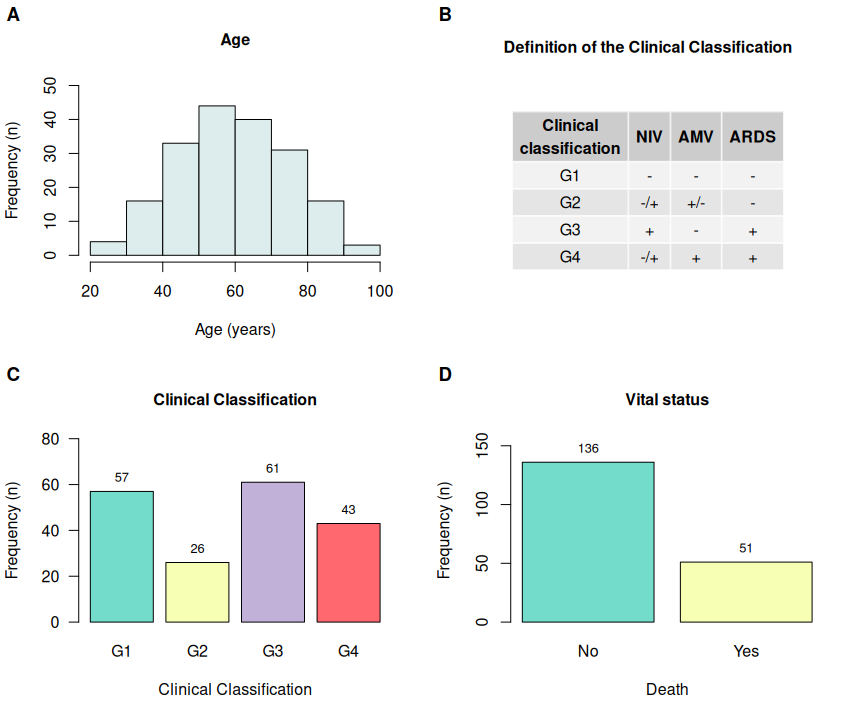

```r
# Generate a list to show all the plots together
figure_1 <- list(plot_1A, plot_1B, plot_1C, plot_1D)

plot_grid(plotlist = figure_1, labels = c("A","B","C","D"))
```

## 3.2 Reproduce Figure 2 from the publication

Instead of representing the clusters in the annotation, represent the groups (G1 to G4)

### 3.2.1 Data Preparation

Since laboratory test time points differ among patients, we compute the median cytokine values per patient to ensure consistency.

```r
data_cytokine <- data_cytokine %>%
  group_by(ID) %>%
  summarise(across(.cols = everything(), .fns = ~ median(.x, na.rm = TRUE)))
```

Since some cytokine values are missing, we apply an imputation method to estimate missing values based on observed data.

```r
imputed_cytokine <- mice(data_cytokine)
completed_data_cytokine<- complete(imputed_cytokine)
selected_data <- completed_data_cytokine[, c(1,3:14)]
```

To categorize patients, we merge the cytokine dataset with metadata containing group classification (G1-G4), death status, and gender.

```r
selected_data <- merge(selected_data, filtered_data[, c("ID", "Group", "Death", "Gender")],
                  by = "ID", all.x = TRUE)

selected_data <- subset(selected_data, !is.na(Group))
```

Before visualization, we transpose the dataset and scale the cytokine values as relative percentages.

```r
heatmap_data <- t(selected_data[, 2:13])

table_to_heatmap <- apply(heatmap_data, 2, function(x) (x / sum(x)) * 100)
```

### 3.2.2 Data Visualization

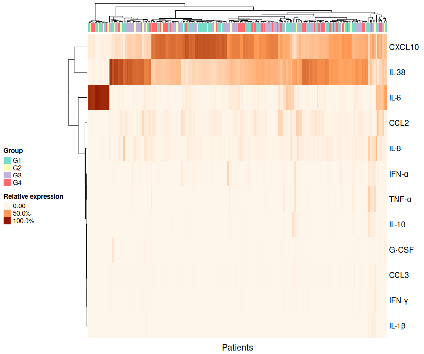

```r
# Create annotation dataframe for patient groups
annotations <- data.frame(Group = selected_data$Group)

# Define colors for each group
heatmap_annotations <- HeatmapAnnotation(df = annotations, show_annotation_name = FALSE, col = list(Group =  c("G1" = "#75dbc8", "G2" = "#f6ffb4",
                                             "G3" = "#c1b0d8", "G4" = "#ff686e")))

custom_colors <- c("#fef6eb", "#ff9953", "#931500")


heatmap <- Heatmap(table_to_heatmap,
              top_annotation = heatmap_annotations,
              col = colorRamp2(c(0, 50, 100), custom_colors),
              column_title = "Patients",
              column_title_side = "bottom",
              show_column_names = F,
              show_heatmap_legend = F)

legend <- Legend(
  title = "Relative expression",
  at = c(0, 50, 100),
  labels = c("0.00", "50.0%", "100.0%"),
  legend_gp = gpar(fill = custom_colors, col = NA)
)

postion_legend <- packLegend(legend, direction = "vertical")

figure_2 <- function() {
  draw(heatmap, annotation_legend_list = postion_legend, annotation_legend_side = "left")
}

figure_2()
```

## 3.3 Improve figure 2 of the publication

Add a second annotation with information of death and a third one with information of gender

Gender column in selected_data is being cleaned and standardized to ensure that only valid gender categories are used. If a value is not recognized, it is replaced with “Unknown”, ensuring data consistency. After standardizing the gender data, the cbind() function is used to combine the existing annotations dataframe with two additional variables: Death status and Gender.

```r
selected_data$Gender <- ifelse(selected_data$Gender %in% c("F", "M"), selected_data$Gender, "Unknown")

improved_annotations <- cbind(annotations, Death = selected_data$Death, Gender = selected_data$Gender )
```

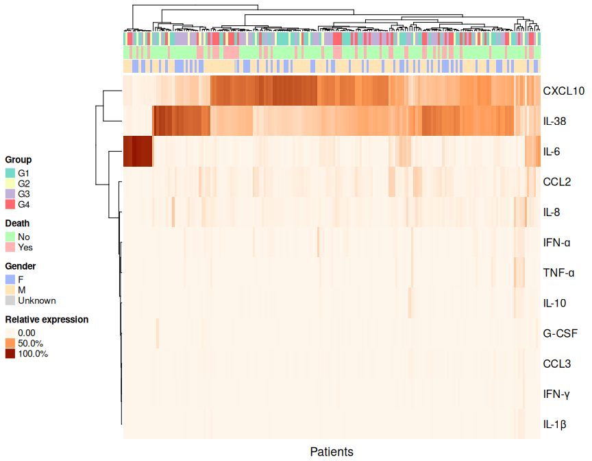

```r
# Define colors for each group
heatmap_annotations_2 <- HeatmapAnnotation(df = improved_annotations, show_annotation_name = FALSE, col = list(
  Group =  c("G1" = "#75dbc8", "G2" = "#f6ffb4", "G3" = "#c1b0d8", "G4" = "#ff686e"),
  Death = c("Yes" = "#FFB3B3", "No" = "#B3FFB3"),
  Gender = c("F" = "#a1b7ff", "M" = "#FFE4B5", "Unknown" = "#D3D3D3")))

custom_colors <- c("#fef6eb", "#ff9953", "#931500")

heatmap_2 <- Heatmap(table_to_heatmap,
               top_annotation = heatmap_annotations_2,
               col = custom_colors,
               column_title = "Patients",
               column_title_side = "bottom",
               row_title_side = "right",
               show_column_names = F,
               show_heatmap_legend = F)

legend_2 <- Legend(
  title = "Relative expression",
  at = c(0, 50, 100),
  labels = c("0.00", "50.0%", "100.0%"),
  legend_gp = gpar(fill = custom_colors, col = NA)
)


postion_legend_2 <- packLegend(legend_2, direction = "vertical")

figure_2b <- function() {
  draw(heatmap_2, annotation_legend_list = postion_legend_2, annotation_legend_side = "left")
}

figure_2b()
```

# session info

R version 4.4.2 (2024-10-31) Platform: x86_64-pc-linux-gnu Running under: Ubuntu 24.04.1 LTS

Matrix products: default BLAS: /usr/lib/x86_64-linux-gnu/blas/libblas.so.3.12.0 LAPACK: /usr/lib/x86_64-linux-gnu/lapack/liblapack.so.3.12.0

locale: [1] LC_CTYPE=en_US.UTF-8 LC_NUMERIC=C  
[3] LC_TIME=en_US.UTF-8 LC_COLLATE=en_US.UTF-8  
[5] LC_MONETARY=en_US.UTF-8 LC_MESSAGES=en_US.UTF-8  
[7] LC_PAPER=en_US.UTF-8 LC_NAME=C  
[9] LC_ADDRESS=C LC_TELEPHONE=C  
[11] LC_MEASUREMENT=en_US.UTF-8 LC_IDENTIFICATION=C

time zone: Europe/Madrid tzcode source: system (glibc)

attached base packages: [1] grid stats graphics grDevices utils datasets methods  
[8] base

other attached packages: [1] circlize_0.4.16 ComplexHeatmap_2.20.0 RColorBrewer_1.1-3  
[4] cowplot_1.1.3 ggthemes_5.1.0 tidyr_1.3.1  
[7] openxlsx_4.2.7.1 readxl_1.4.3 gridExtra_2.3  
[10] ggplot2_3.5.1 corrplot_0.95 mice_3.17.0  
[13] dplyr_1.1.4 readr_2.1.5

loaded via a namespace (and not attached): [1] Rdpack_2.6.2 tcltk_4.4.2 rlang_1.1.5  
[4] magrittr_2.0.3 clue_0.3-66 GetoptLong_1.0.5  
[7] matrixStats_1.5.0 compiler_4.4.2 png_0.1-8  
[10] vctrs_0.6.5 reshape2_1.4.4 stringr_1.5.1  
[13] pkgconfig_2.0.3 shape_1.4.6.1 crayon_1.5.3  
[16] summarytools_1.0.1 fastmap_1.2.0 backports_1.5.0  
[19] magick_2.8.5 labeling_0.4.3 pander_0.6.5  
[22] rmarkdown_2.29 tzdb_0.4.0 nloptr_2.1.1  
[25] purrr_1.0.2 xfun_0.50 glmnet_4.1-8  
[28] jomo_2.7-6 cachem_1.1.0 jsonlite_1.8.9  
[31] pan_1.9 pryr_0.1.6 broom_1.0.7  
[34] parallel_4.4.2 cluster_2.1.8 R6_2.5.1  
[37] bslib_0.8.0 stringi_1.8.4 boot_1.3-31  
[40] rpart_4.1.24 lubridate_1.9.4 jquerylib_0.1.4  
[43] cellranger_1.1.0 Rcpp_1.0.14 iterators_1.0.14  
[46] knitr_1.49 base64enc_0.1-3 IRanges_2.38.1  
[49] Matrix_1.7-1 splines_4.4.2 nnet_7.3-20  
[52] timechange_0.3.0 tidyselect_1.2.1 rstudioapi_0.17.1  
[55] yaml_2.3.10 doParallel_1.0.17 codetools_0.2-20  
[58] lattice_0.22-5 tibble_3.2.1 plyr_1.8.9  
[61] withr_3.0.2 evaluate_1.0.3 gridGraphics_0.5-1 [64] survival_3.8-3 zip_2.3.1 pillar_1.10.1  
[67] checkmate_2.3.2 foreach_1.5.2 stats4_4.4.2  
[70] reformulas_0.4.0 generics_0.1.3 hms_1.1.3  
[73] S4Vectors_0.42.1 munsell_0.5.1 scales_1.3.0  
[76] minqa_1.2.8 glue_1.8.0 tools_4.4.2  
[79] lme4_1.1-36 rapportools_1.1 rbibutils_2.3  
[82] colorspace_2.1-1 nlme_3.1-166 cli_3.6.3  
[85] gtable_0.3.6 sass_0.4.9 digest_0.6.37  
[88] BiocGenerics_0.50.0 farver_2.1.2 rjson_0.2.23  
[91] htmltools_0.5.8.1 lifecycle_1.0.4 GlobalOptions_0.1.2 [94] mitml_0.4-5 MASS_7.3-64